# Bank Data Analysis

## Zbiór danych

Do dyspozycji mamy dane dotyczące kampanii marketingowej Portugalskiego banku. Naszym zadaniem było przewidywanie czy klient założy w tym banku lokatę terminową.

Zbiór danych zawiera następujące informacje:

- Age - Wiek.
- Job - Rodzaj wykonywanej pracy.
- Marital - Status cywilny.
- Education - Poziom wykształcenia.
- Default - Czy ma niespłacony kredyt?
- Balance: Średni roczny balans konta (w euro).
- Housing: Czy ma kredyt mieszkaniowy?
- Loan: Czy ma pożyczkę osobistą?
- Contact: Typ komunikacji
- Day: Dzień miesiąca ostatniego kontaktu.
- Month: Miesiąc ostatniego kontaktu.
- Duration: Długość ostatniego kontaktu (w sekundach).
- Campaign: Liczba kontaktów w trakcie obecnaj kampanii z danym klientem.
- Pdays: Liczba dni od ostatniego kontaktu podczas poprzedniej kampanii.
- Previous: Liczba kontaktów z danym klientem przed obecną kampanią.
- Poutcome: Wynik poprzedniej kampanii marketingowej.
- Y: Czy klient utworzył lokatę terminową?

## Eksploracja danych

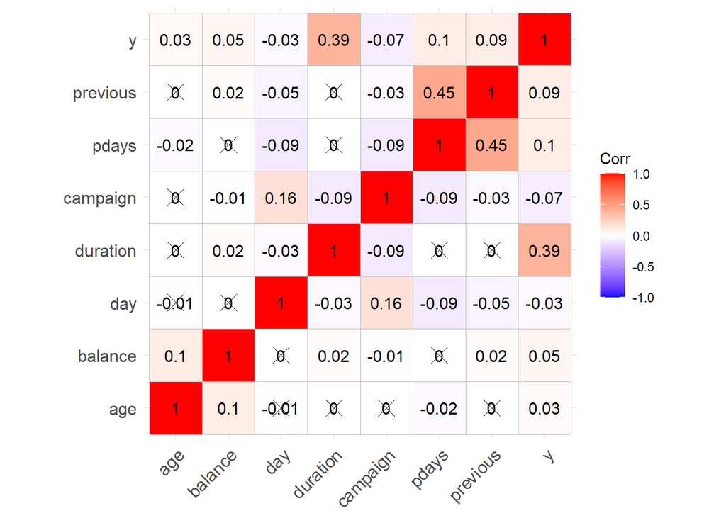

Poza czasem trwania rozmowy żadna inna zmienna numeryczna nie jest istotnie skorelowana z subskrybcją lokaty terminowej (y). Długość rozmowy może być znacząca, dlatego że może świadczyć o większym zainteresowaniu. Im dłużej prowadzona jest rozmowa tym bliższy jest temat konsumentowi przez co jest bardziej chętny do subskrypcji lokaty.

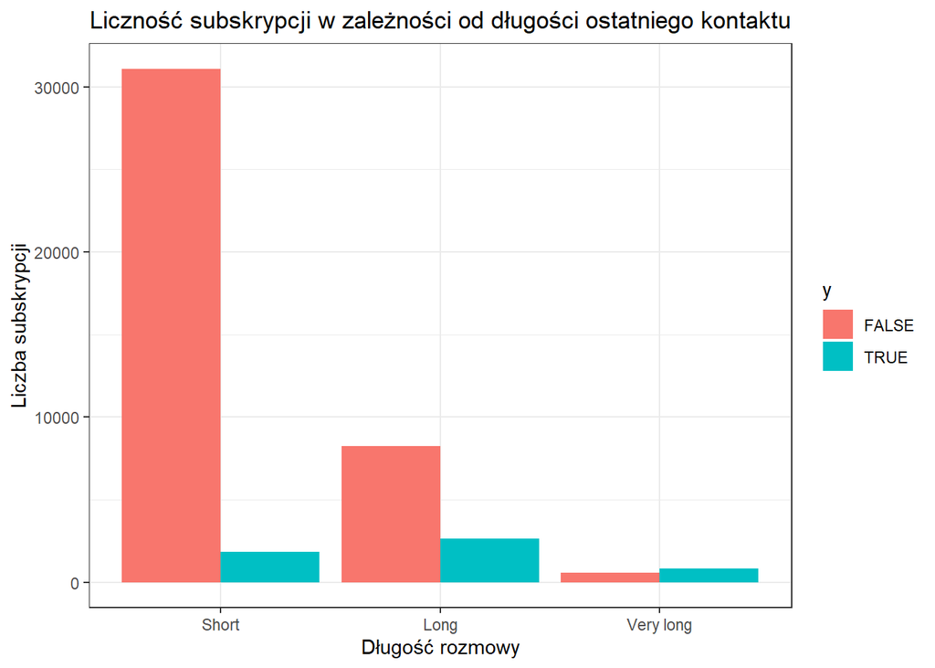

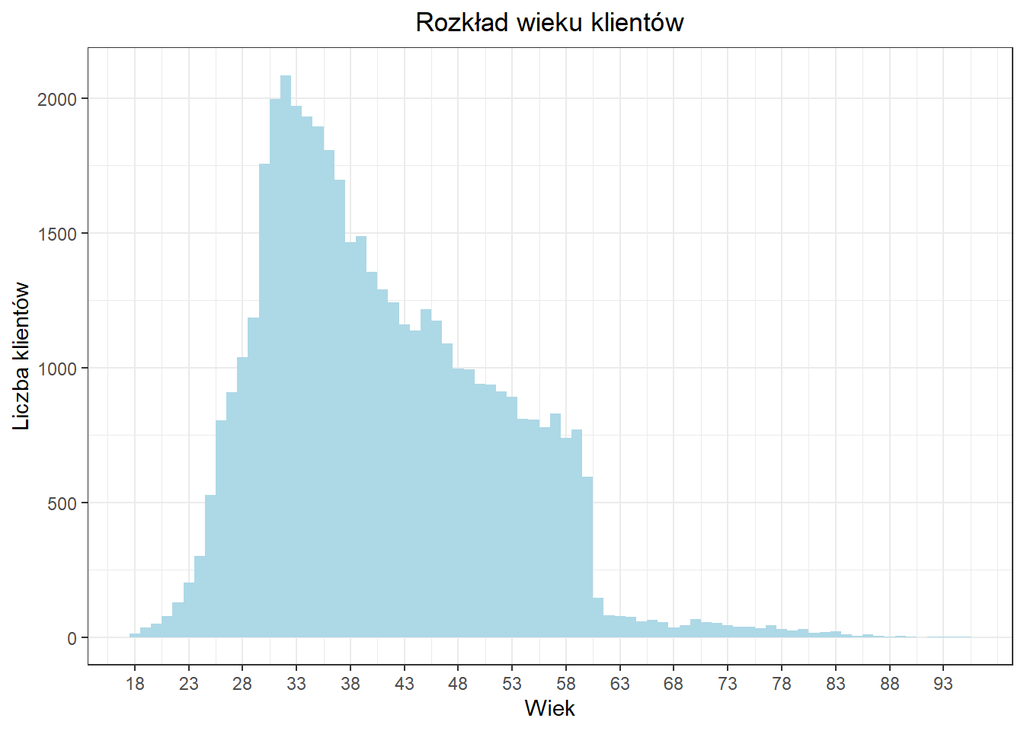

Najwięcej klientów banku jest w wieku 32 lat. Występuje nagły spadek klientów w wieku powyżej 60 lat.

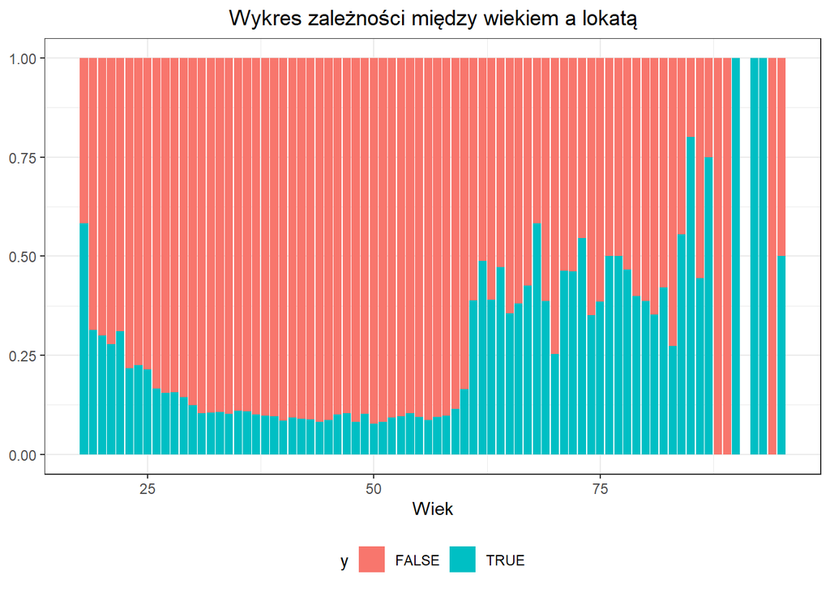

Istnieje związek pomiędzy wiekiem, a skłonnością do zakładania lokat. Młodzi oraz seniorzy są bardziej skłonni do zakładania lokat w porównaniu do osób w średnim wieku.

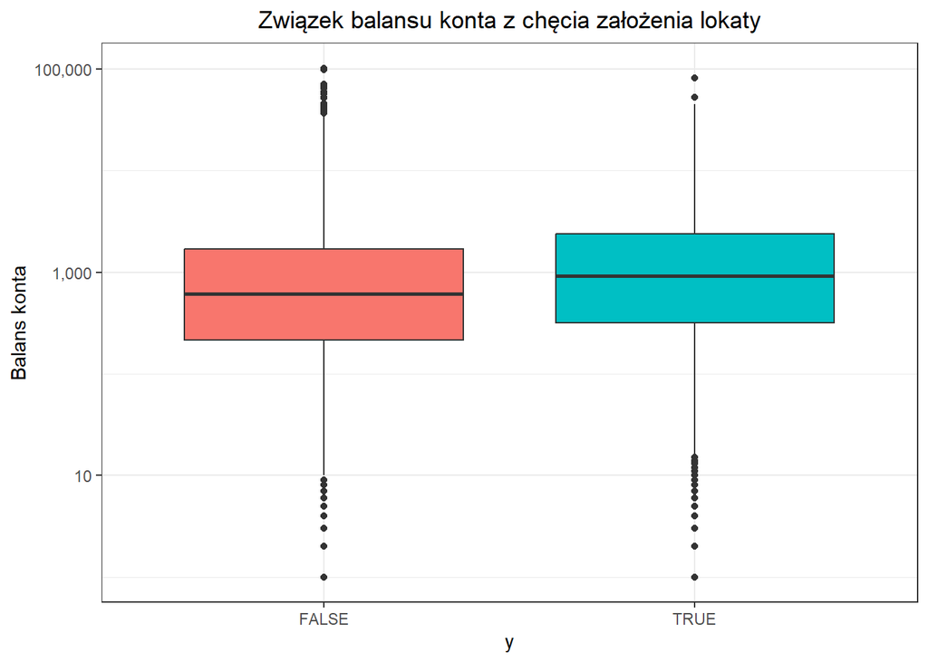

Osoby z większym saldem konta mają większą skłonność do pozostawienia pieniędzy na lokacie.

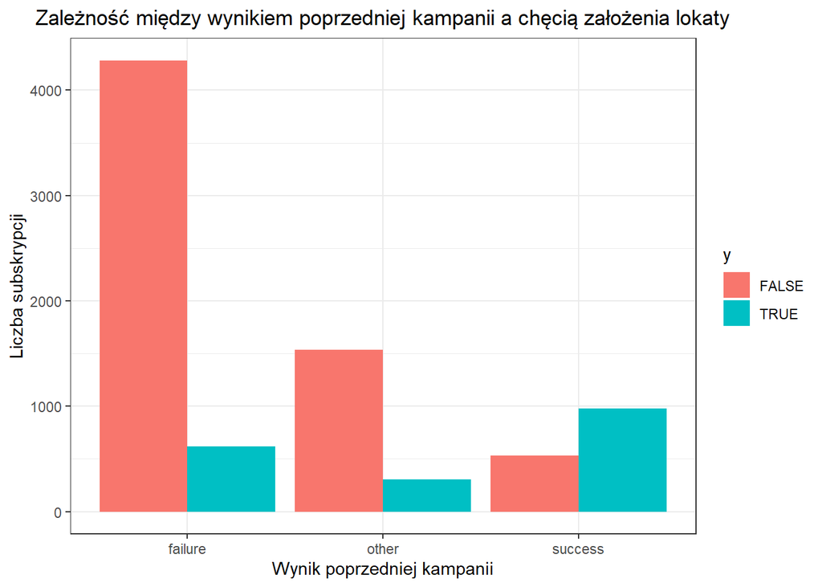

Oznacza to, że wynik poprzedniej kampanii może mieć wpływ na zachowania subskrypcyjne w bieżącej kampanii, co sugeruje związek między tymi zmiennymi.

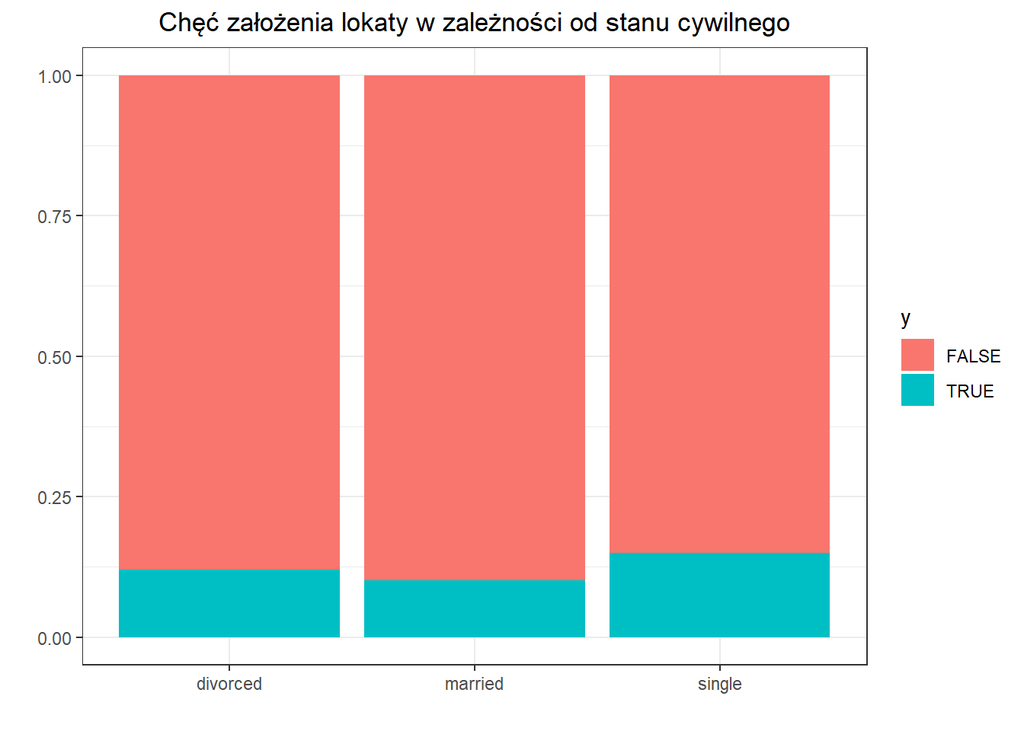

Nie ma widocznego związku między stanem cywilnym a założeniem lokaty długoterminowej.

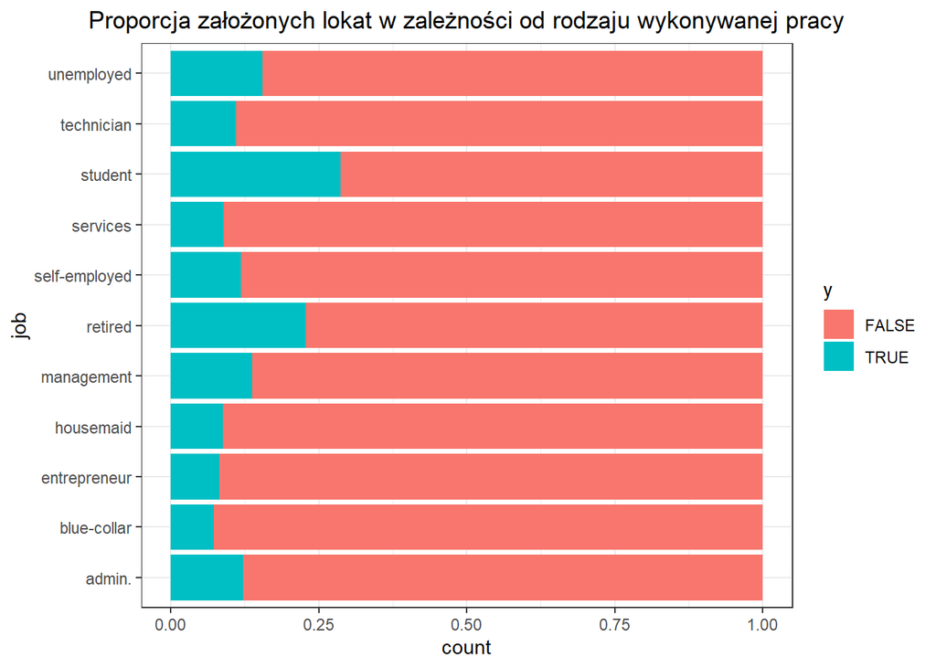

Dane sugerują, że status stanowiska może mieć pewien wpływ na subskrypcję lokaty terminowej, o czym świadczy różna liczba wyników w różnych kategoriach stanowisk. Jednak ta relacja nie jest prosta ani spójna w przypadku wszystkich typów stanowisk, co wskazuje, że inne czynniki mogą również odgrywać rolę w określaniu zachowania subskrypcji.

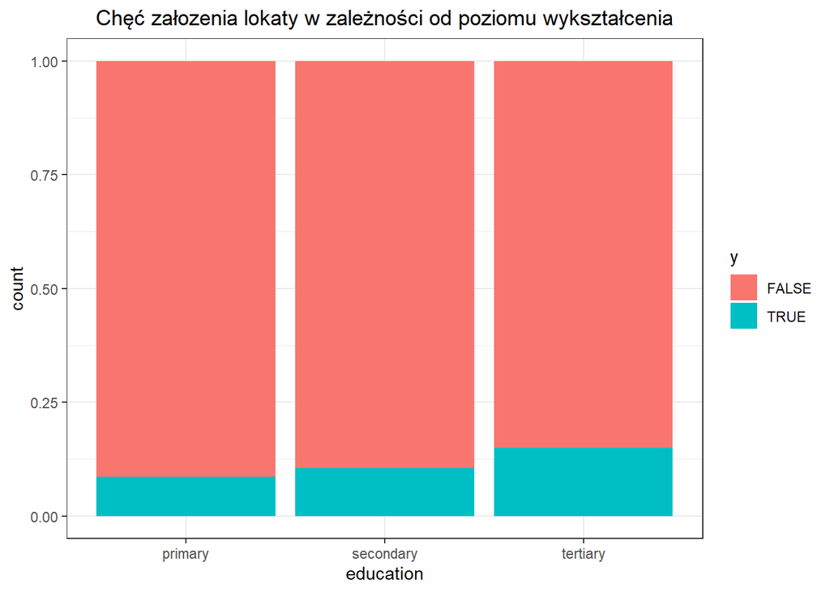

Dane sugerują związek pomiędzy poziomem wykształcenia a abonamentem na lokatę terminową. Wydaje się, że wyższy poziom wykształcenia, zwłaszcza wyższego, wiąże się z większym prawdopodobieństwem zapisania się na lokatę terminową.

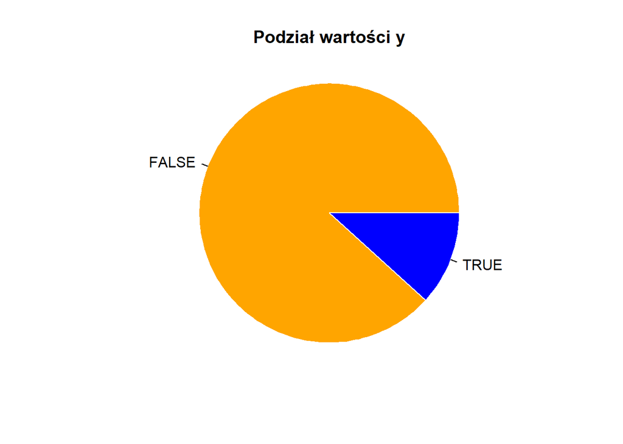

Mamy do czynienia z niezbalansowaniem danych, co będzie istotne w procesie tworzenia modeli

## Budowa modeli

Modela jakie stworzyliśmy to:

- Random Forest
- Decision Tree
- XGBoost
- KNN
- SVM
- Logistic Regression Do tunowania hiperparametrów wykorzystywaliśmy walidację krzyżową.

| Metric | Random Forest | SVM | KNN | Decision Tree | Logistic Regression | Boosting |
| --- | --- | --- | --- | --- | --- | --- |
| F1 score | 0.934166146158651 | 0.886250168668196 | 0.912325941206808 | 0.926602039531663 | 0.883802816901408 | 0.939620758483034 |
| Accuracy | 0.886348932499461 | 0.818201423334052 | 0.853353461289627 | 0.874272158723312 | 0.814966573215441 | 0.895622169506146 |
| Sensitivity | 0.943001261034048 | 0.828247162673392 | 0.892307692307692 | 0.9281210592686 | 0.822950819672131 | 0.949810844892812 |
| Specificity | 0.552083333333333 | 0.758928571428571 | 0.623511904761905 | 0.556547619047619 | 0.767857142857143 | 0.575892857142857 |
| Recall | 0.943001261034048 | 0.828247162673392 | 0.892307692307692 | 0.9281210592686 | 0.822950819672131 | 0.949810844892812 |
| J index | 0.495084594367381 | 0.587175734101963 | 0.515819597069597 | 0.484668678316219 | 0.590807962529274 | 0.525703702035669 |
| roc_auc | 0.921443959046418 | 0.869976505734702 | 0.860486849216357 | 0.895364198642887 | 0.872508331832102 | 0.927563351948598 |

Na pierwszy rzut oka widać, że Boosting jest najbardziej efektywnym modelem. Zaraz po nim najlepiej z zadaniem klasyfikacji radzi sobie Random Forest.

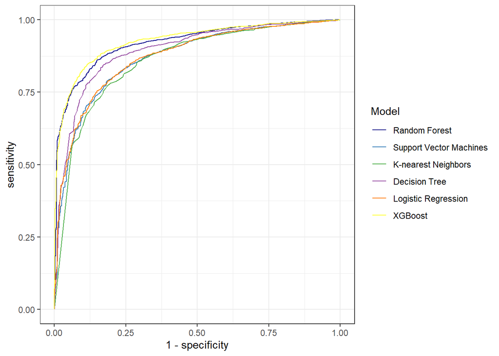

Na wykresie krzywych roc auc najgorzej wyszedł model KNN. Najlepiej wspomniany wcześniej XGBoost.

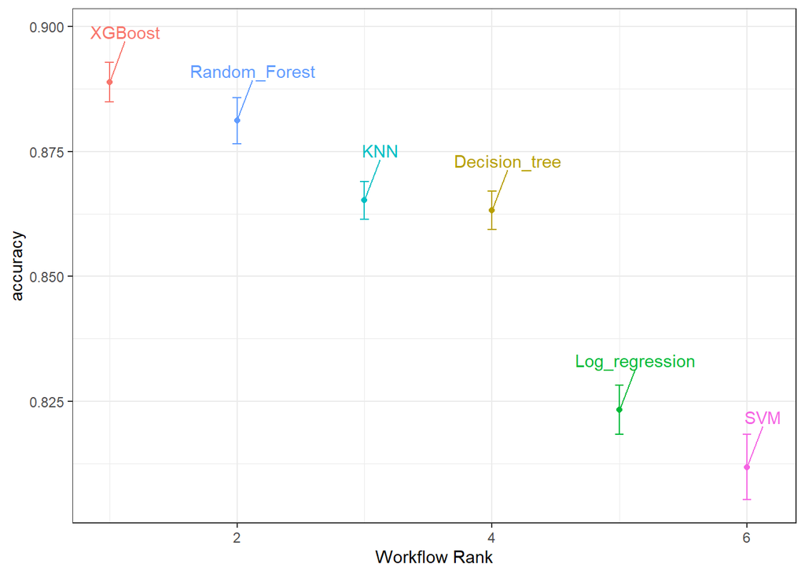

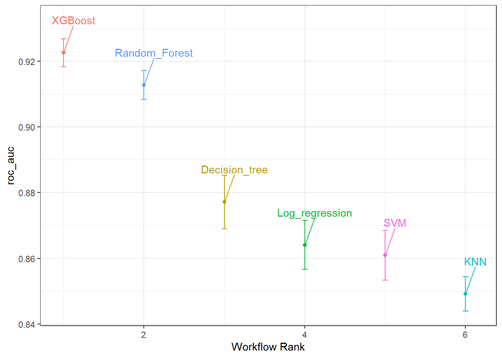

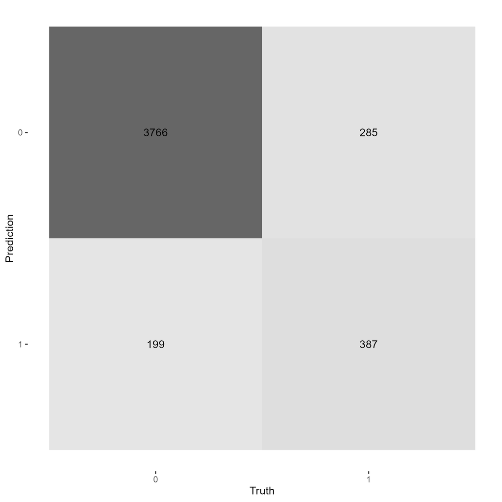

## Wnioski końcowe

Przy tworzeniu tego projektu nauczyliśmy się rozwiązywać niespotkane do tej pory problemy, takie jak niezbalansowanie danych czy praca pod presją czasu ;). Nauczyliśmy się pracy z biblioteką tidymodels. Poznaliśmy nowe modele uczenia maszynowego oraz poprawiliśmy umiejętności pracy w grupie.